# A brief introduction to the sf package

## sf : the tidy way of working with spatial data in R

The sf package is the (relatively) new kid on the block when it comes to working with spatial data in R. It provides a much more intuitive way and is easier to learn that the sp package. It provides a syntax and data-structures which are coherent with the tidyverse. A quick introduction can be found here: https://mhweber.github.io/gis_in_action_r_spatial/2017/04/18/05-Spatial-Data-In-R-sf

## Plotting a map the old way

After reading in the shapefile you need to fortify it to be able to join the values which should be used to colour the map to it and plot it. Also the ‘mapdata’ dataset is created with the sole purpouse of generating the map : it contains a row for every edge-point which composes the polygons and to each point the value for the municipality mapped.

```r
library(pacman)
pacman::p_load(rgdal,ggplot2)
#read shapefile with rgdal (in past i've regularly used maptools::readShapePoly) this results in a nested datastructure (lists within lists) which is hard to decompose
shape <- readOGR("geodata/Shape_detailliert_SEEN_2016/UP_GEMEINDEN_SEEN_2016_F.shp")
#fortify -> generates a dataframe which ggplot2 can handle from a spatial object
shape2 <- fortify(shape, region='BFS')
# Dataset (Motorization and "generalabonnement"-owners)
mfz_ga <-readRDS("mfz_ga.rds")
#merge data with shapefile
mapdata <- merge(shape2, mfz_ga, by.x="id", by.y="bfs",all.x = TRUE, all.y = TRUE)
mapdata <- mapdata[order(mapdata$order),]
#how does the df look like?
mapdata[11300:11310,]
```

|  | id | long | lat | order | hole | piece | group | gemeinde | mfzpro100ew | Gde_Nam | Kanton | GA | HTA | Anzahl_Einw | Anteil_GA | Anteil_HTA |
| --- | --- | --- | --- | --- | --- | --- | --- | --- | --- | --- | --- | --- | --- | --- | --- | --- |
| 11300 | 10 | 2675433 | 1234946 | 11300 | FALSE | 1 | 10.1 | Obfelden | 757 | Obfelden | ZH | 264 | 1597 | 5009 | 5.3 | 31.9 |
| 11301 | 10 | 2675421 | 1234944 | 11301 | FALSE | 1 | 10.1 | Obfelden | 757 | Obfelden | ZH | 264 | 1597 | 5009 | 5.3 | 31.9 |
| 11302 | 10 | 2675417 | 1234943 | 11302 | FALSE | 1 | 10.1 | Obfelden | 757 | Obfelden | ZH | 264 | 1597 | 5009 | 5.3 | 31.9 |
| 11303 | 10 | 2675397 | 1234932 | 11303 | FALSE | 1 | 10.1 | Obfelden | 757 | Obfelden | ZH | 264 | 1597 | 5009 | 5.3 | 31.9 |
| 11304 | 10 | 2675373 | 1234916 | 11304 | FALSE | 1 | 10.1 | Obfelden | 757 | Obfelden | ZH | 264 | 1597 | 5009 | 5.3 | 31.9 |
| 11305 | 10 | 2675339 | 1234893 | 11305 | FALSE | 1 | 10.1 | Obfelden | 757 | Obfelden | ZH | 264 | 1597 | 5009 | 5.3 | 31.9 |
| 11306 | 10 | 2675335 | 1234889 | 11306 | FALSE | 1 | 10.1 | Obfelden | 757 | Obfelden | ZH | 264 | 1597 | 5009 | 5.3 | 31.9 |
| 11307 | 10 | 2675316 | 1234874 | 11307 | FALSE | 1 | 10.1 | Obfelden | 757 | Obfelden | ZH | 264 | 1597 | 5009 | 5.3 | 31.9 |
| 11308 | 10 | 2675228 | 1234802 | 11308 | FALSE | 1 | 10.1 | Obfelden | 757 | Obfelden | ZH | 264 | 1597 | 5009 | 5.3 | 31.9 |
| 11309 | 10 | 2675203 | 1234787 | 11309 | FALSE | 1 | 10.1 | Obfelden | 757 | Obfelden | ZH | 264 | 1597 | 5009 | 5.3 | 31.9 |

[output cut: 1 more lines]

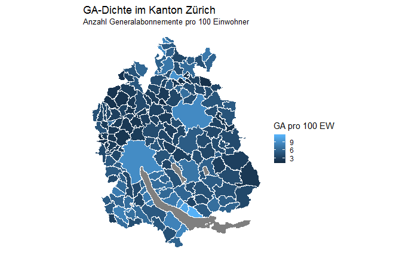

```r
# ggplot mapping  # data layer
ggplot(data=mapdata,aes(x=long, y=lat, group=group)) +
  geom_path(color='gray') +
  coord_equal()+
  geom_polygon(aes(fill=Anteil_GA),color = "white")+
  theme_void()+
  theme(legend.key.size = unit(1,"line"),
  #Grösse Legende
  legend.key.height= unit(0.5,"line"))+
  scale_fill_continuous(name="GA pro 100 EW")+
  labs(title="GA-Dichte im Kanton Zürich",
       subtitle="Anzahl Generalabonnemente pro 100 Einwohner",x="",y="")
```

## Plotting maps the ‘tidy’ way with the sf-package

```r
library(pacman)
pacman::p_load(sp, sf,tidyverse,gghighlight)
#Shapefile (municipalities) - read_sf generates a tidy dataset, each row represents one municipality, the polygons are stored in a single special geo-variable, the 'geometry' column
gemeinden<- read_sf('geodata/Shape_detailliert_SEEN_2016', stringsAsFactors = FALSE)
# Dataset (Motorization and GA-owners)
mfz_ga <-readRDS("mfz_ga.rds")
#join data - the dataset-structure stays the same, just
gemdata <-gemeinden %>% left_join(mfz_ga, by=c("BFS"="bfs"))
#how does the df with class "sf" look like?
head(gemdata)
```

```
Simple feature collection with 6 features and 18 fields
geometry type:  POLYGON
dimension:      XY
bbox:           xmin: 2678391 ymin: 1267225 xmax: 2703205 ymax: 1272602
epsg (SRID):    NA
proj4string:    +proj=somerc +lat_0=46.95240555555556 +lon_0=7.439583333333333 +k_0=1 +x_0=2600000 +y_0=1200000 +ellps=bessel +units=m +no_defs
```

| BFS | ARPS | BEZIRKSNAM | ART_TEXT | GEMEINDENA | ART_CODE | AREA_ROUND | SHAPE_AREA | SHAPE_LEN | gemeinde | mfzpro100ew | Gde_Nam | Kanton | GA | HTA | Anzahl_Einw | Anteil_GA | Anteil_HTA | geometry |
| --- | --- | --- | --- | --- | --- | --- | --- | --- | --- | --- | --- | --- | --- | --- | --- | --- | --- | --- |
| 39 | 136 | Andelfingen | Gemeinde | Thalheim an der Thur | 1 | 6442349 | 6442295 | 15045.26 | Thalheim a.d.Th. | 897 | Thalheim an der Thur | ZH | 31.0000 | 295.000 | 904 | 3.4 | 32.6 |  |
| 211 | 118 | Winterthur | Gemeinde | Altikon | 1 | 7697778 | 7697801 | 13908.60 | Altikon | 1025 | Altikon | ZH | 12.3088 | 245.000 | 655 | 1.9 | 37.4 |  |
| 55 | 146 | Bülach | Gemeinde | Eglisau | 1 | 9063185 | 9063074 | 25597.11 | Eglisau | 710 | Eglisau | ZH | 251.0180 | 1778.626 | 5026 | 5.0 | 35.4 |  |
| 26 | 124 | Andelfingen | Gemeinde | Dorf | 1 | 5557450 | 5557388 | 13600.19 | Dorf | 955 | Dorf | ZH | 32.0000 | 222.000 | 624 | 5.1 | 35.6 |  |
| 43 | 140 | Andelfingen | Gemeinde | Volken | 1 | 3202456 | 3202410 | 11286.97 | Volken | 991 | Volken | ZH | 12.3088 | 106.000 | 339 | 3.6 | 31.3 |  |
| 32 | 129 | Andelfingen | Gemeinde | Humlikon | 1 | 3677404 | 3677356 | 14736.86 | Humlikon | 782 | Humlikon | ZH | 12.3088 | 201.000 | 504 | 2.4 | 39.9 |  |

```
plotting the first 10 out of 18 attributes; use max.plot = 18 to plot all
```

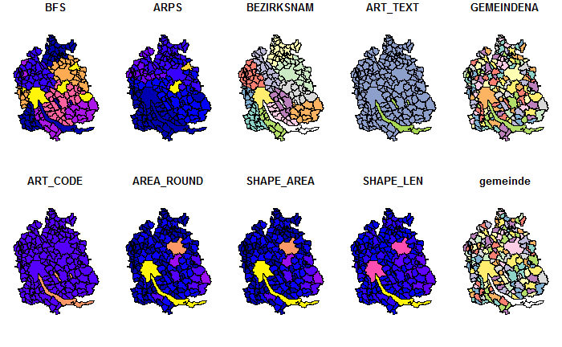

```r
# dataframe with class sf can easily be ploted to get an overview! not so with sp...
plot(gemdata)
```

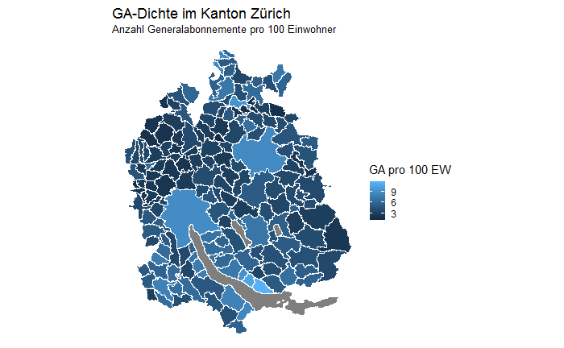

```r
#map with ggplot2
sfmap <-ggplot()+
  geom_sf(data=gemdata,aes(fill=Anteil_GA),color = "white")+
  coord_sf(datum = NA)+
  theme_void()+#Koordinatennetz verbergen
  theme(legend.key.size = unit(1,"line"),
  legend.key.height= unit(0.5,"line"))+
  scale_fill_continuous(name="GA pro 100 EW")+
  labs(title="GA-Dichte im Kanton Zürich",
       subtitle="Anzahl Generalabonnemente pro 100 Einwohner",x="",y="")
sfmap
```

## sf dataframes: just a data.frame with a special geo-variable! We can use it like an ordinary structured dataframe.

```
Using BEZIRKSNAM as label for now, but please provide the label_key explicity!
```

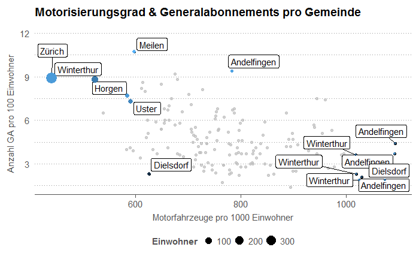

```r
library(gghighlight)
#library(devtools)
#install_github(statistikZH/statR)
library(statR)
gghighlight_point(gemdata, aes(mfzpro100ew,Anteil_GA),Anteil_GA > 7 & mfzpro100ew<600 |
                    mfzpro100ew>1000|
                    mfzpro100ew<700 & Anteil_GA<3|
                    mfzpro100ew>750 & Anteil_GA>9)+
  geom_point(aes(size=Anzahl_Einw/1000, color=Anteil_HTA))+
  theme_stat()+
  scale_size(name="Einwohner")+
  labs(title="Motorisierungsgrad & Generalabonnements pro Gemeinde\n",
       y="Anzahl GA pro 100 Einwohner",x="Motorfahrzeuge pro 1000 Einwohner")
```

## This was just a foretaste…

Imagine we have several shapefiles which we want to plot layer by layer. With the old way we would need to fortify each shapefile…

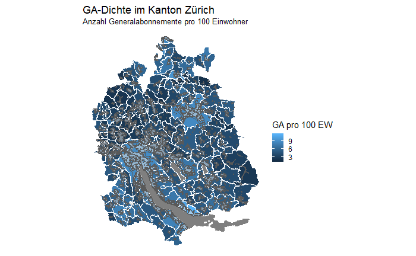

```r
# Shapefiles of the "Handlungsräume & Bauzonen"
handlungsraum<- st_read("geodata/handlungsraeume", stringsAsFactors = FALSE)
bauzonen <- st_read("geodata/bauzonen", stringsAsFactors = FALSE)
sfmap+
  geom_sf(data=handlungsraum,fill=NA)+
  geom_sf(data=bauzonen,alpha=0.5)+
  coord_sf(datum = NA)
```

```r
# #CRS CH LV95 -> swiss projection
# st_crs(gemeinden)<- "+init=epsg:2056"
#Projektion wgs 84 lat lng
# sbb <- st_transform(sbb,"+init=epsg:4326 +proj=somerc +lat_0=46.95240555555556 +lon_0=7.439583333333333 +k_0=1 +x_0=2600000 +y_0=1200000 +ellps=bessel +units=m +no_defs")
```